# Tugas Praktikum MPDW (5-7)

Fatima Azzahra - G1401231036

2025-09-30

```r
library("lubridate")
library("readr")
library("readxl")
library("dplyr")
library("forecast")
```

```r
library("graphics")
library("TTR")
library("TSA")
library("ggplot2")
```

```r
library(tseries)
library(tsibble)
library(MASS)
```

# Import Data

**Deskripsi**  
Dataset ini merupakan pencatatan berbagai macam komponen terkait cuaca dengan periode pencatatan per 10 menit dari tanggal 1 Januari 2020 sampai 31 Desember 2020. Analisis akan difokuskan pada peubah VPdef (Vapor Pressure Deficit).

Terkait cakupan analisis untuk tugas ini, akan dianalisis 100 baris pertama untuk peubah VPdef dengan cakupan periodenya yaitu 1 Januari 2020 pada menit ke-10 sampai 16:40.

```r
weather <- read_csv("D:\\TAHUN 3\\G1_MPDW\\cleaned_weather.csv")
View(weather)
str(weather)
```

```
## spc_tbl_ [52,696 × 21] (S3: spec_tbl_df/tbl_df/tbl/data.frame)
##  $ date    : chr [1:52696] "1/1/2020 0:10" "1/1/2020 0:20" "1/1/2020 0:30" "1/1/2020 0:40" ...
##  $ p       : num [1:52696] 1009 1009 1009 1009 1009 ...
##  $ T       : num [1:52696] 0.71 0.75 0.73 0.37 0.33 0.34 0.19 0.03 0.11 0.22 ...
##  $ Tpot    : num [1:52696] 273 273 273 273 273 ...
##  $ Tdew    : num [1:52696] -1.33 -1.44 -1.48 -1.64 -1.5 -1.54 -1.65 -1.7 -1.61 -1.62 ...
##  $ rh      : num [1:52696] 86.1 85.2 85.1 86.3 87.4 87.1 87.4 88.1 88.1 87.4 ...
##  $ VPmax   : num [1:52696] 6.43 6.45 6.44 6.27 6.26 6.26 6.19 6.12 6.16 6.2 ...
##  $ VPact   : num [1:52696] 5.54 5.49 5.48 5.41 5.47 5.45 5.41 5.39 5.43 5.42 ...
##  $ VPdef   : num [1:52696] 0.89 0.95 0.96 0.86 0.79 0.81 0.78 0.73 0.73 0.78 ...
##  $ sh      : num [1:52696] 3.42 3.39 3.39 3.35 3.38 3.37 3.34 3.33 3.35 3.35 ...
##  $ H2OC    : num [1:52696] 5.49 5.45 5.43 5.37 5.42 5.41 5.37 5.35 5.38 5.38 ...
##  $ rho     : num [1:52696] 1281 1280 1280 1282 1282 ...
##  $ wv      : num [1:52696] 1.02 0.43 0.61 1.11 0.49 0.63 0.88 1.05 0.9 0.62 ...
##  $ max. wv : num [1:52696] 1.6 0.84 1.48 1.48 1.4 1.32 1.28 1.64 1.72 1.04 ...
##  $ wd      : num [1:52696] 224 207 197 206 210 ...
##  $ rain    : num [1:52696] 0 0 0 0 0 0 0 0 0 0 ...
##  $ raining : num [1:52696] 0 0 0 0 0 0 0 0 0 0 ...
##  $ SWDR    : num [1:52696] 0 0 0 0 0 0 0 0 0 0 ...
##  $ PAR     : num [1:52696] 0 0 0 0 0 0 0 0 0 0 ...
##  $ max. PAR: num [1:52696] 0 0 0 0 0 0 0 0 0 0 ...
##  $ Tlog    : num [1:52696] 11.4 11.5 11.6 11.7 11.8 ...
##  - attr(*, "spec")=
##   .. cols(
##   ..   date = col_character(),
##   ..   p = col_double(),
##   ..   T = col_double(),
##   ..   Tpot = col_double(),
##   ..   Tdew = col_double(),
##   ..   rh = col_double(),
##   ..   VPmax = col_double(),
##   ..   VPact = col_double(),
##   ..   VPdef = col_double(),
##   ..   sh = col_double(),
##   ..   H2OC = col_double(),
##   ..   rho = col_double(),
##   ..   wv = col_double(),
##   ..   `max. wv` = col_double(),
##   ..   wd = col_double(),
##   ..   rain = col_double(),
##   ..   raining = col_double(),
##   ..   SWDR = col_double(),
##   ..   PAR = col_double(),
##   ..   `max. PAR` = col_double(),
##   ..   Tlog = col_double()
##   .. )
##  - attr(*, "problems")=<externalptr>
```

```r
# Change date format from chr to datetime
weather <- weather %>%
  mutate(datetime = mdy_hm(date))
# new dataframe with datetime and VPdef as respond variable
weather1 <- weather %>%
  dplyr::select(datetime, VPdef)
View(weather1)
str(weather1)
```

```
## tibble [52,696 × 2] (S3: tbl_df/tbl/data.frame)
##  $ datetime: POSIXct[1:52696], format: "2020-01-01 00:10:00" "2020-01-01 00:20:00" ...
##  $ VPdef   : num [1:52696] 0.89 0.95 0.96 0.86 0.79 0.81 0.78 0.73 0.73 0.78 ...
```

```r
# Check if there's missing value from time frequency per day
weather1 %>%
  group_by(date_only = as.Date(datetime)) %>%
  summarise(n_obs = n(), .groups = "drop") %>%
  filter(n_obs != 144)
```

```
## # A tibble: 4 × 2
##   date_only  n_obs
##   <date>     <int>
## 1 2020-01-01   143
## 2 2020-05-12   145
## 3 2020-05-29   135
## 4 2021-01-01     1
```

**Note: Missing Value and Duplicate**

```r
# Create the data subset
w1 <- weather1[1:100,]
head(w1, 20)
```

```
## # A tibble: 20 × 2
##    datetime            VPdef
##    <dttm>              <dbl>
##  1 2020-01-01 00:10:00  0.89
##  2 2020-01-01 00:20:00  0.95
##  3 2020-01-01 00:30:00  0.96
##  4 2020-01-01 00:40:00  0.86
##  5 2020-01-01 00:50:00  0.79
##  6 2020-01-01 01:00:00  0.81
##  7 2020-01-01 01:10:00  0.78
##  8 2020-01-01 01:20:00  0.73
##  9 2020-01-01 01:30:00  0.73
## 10 2020-01-01 01:40:00  0.78
## 11 2020-01-01 01:50:00  0.76
## 12 2020-01-01 02:00:00  0.66
## 13 2020-01-01 02:10:00  0.69
## 14 2020-01-01 02:20:00  0.72
## 15 2020-01-01 02:30:00  0.67
## 16 2020-01-01 02:40:00  0.72
## 17 2020-01-01 02:50:00  0.69
## 18 2020-01-01 03:00:00  0.7
## 19 2020-01-01 03:10:00  0.68
## 20 2020-01-01 03:20:00  0.62
```

```r
View(w1)
```

```r
# Change the data format to time series using 'ts' function
w1.ts <- ts(w1$VPdef)
summary(w1.ts)
```

```
##    Min. 1st Qu.  Median    Mean 3rd Qu.    Max.
##  0.2500  0.3475  0.7250  0.9988  1.5225  2.7000
```

```r
w1.ts
```

```
## Time Series:
## Start = 1
## End = 100
## Frequency = 1
##   [1] 0.89 0.95 0.96 0.86 0.79 0.81 0.78 0.73 0.73 0.78 0.76 0.66 0.69 0.72 0.67
##  [16] 0.72 0.69 0.70 0.68 0.62 0.54 0.53 0.52 0.52 0.48 0.47 0.52 0.42 0.41 0.36
##  [31] 0.40 0.34 0.32 0.32 0.30 0.30 0.29 0.27 0.26 0.25 0.25 0.26 0.29 0.31 0.30
##  [46] 0.29 0.28 0.27 0.27 0.27 0.26 0.30 0.31 0.29 0.30 0.32 0.35 0.38 0.38 0.47
##  [61] 0.69 0.77 0.78 0.75 0.80 0.75 0.82 0.84 0.89 0.90 0.97 1.15 1.27 1.33 1.50
##  [76] 1.59 1.82 1.93 1.95 2.01 2.34 2.36 2.45 2.33 2.18 2.27 2.40 2.39 2.58 2.70
##  [91] 2.52 2.43 2.59 2.64 2.62 2.36 2.12 2.01 1.98 1.94
```

**Note: Time Series Data Frequency**

Pada tahap eksplorasi awal ini digunakan frequency = 1 karena baru mengamati observasi dalam skala yang kecil.

# Eksplorasi Data

## Plot TS Penuh

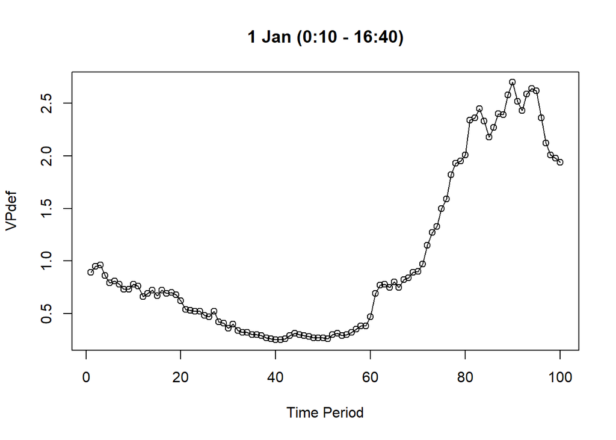

```r
ts.plot(w1.ts, xlab="Time Period", ylab="VPdef",
        main = "1 Jan (0:10 - 16:40)")
points(w1.ts)
```

Berdasarkan plot, data deret waktunya mengindikasikan **tidak stasioner pada rataam dan ragam**.

**Pembagian Data Latih dan Data Uji**

```r
#split training data and testing data
training <- w1[1:80,]
testing <- w1[81:100,]
train.ts <- ts(training$VPdef)
test.ts <- ts(testing$VPdef)
```

## Plot TS Latih

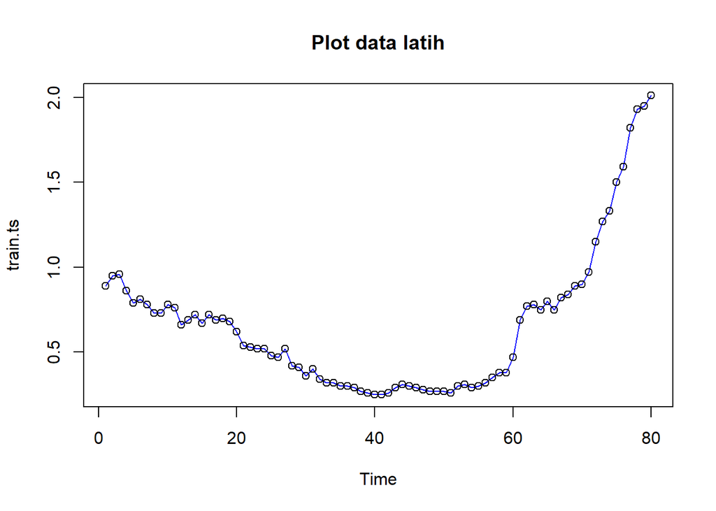

```r
# explore training data
plot(train.ts, col="blue",main="Plot data latih")
points(train.ts)
```

## Plot TS Uji

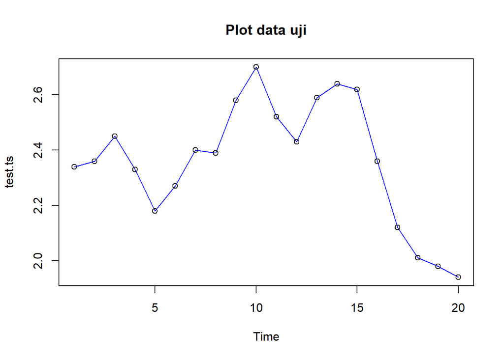

```r
# explore testing data
plot(test.ts, col="blue",main="Plot data uji")
points(test.ts)
```

# Uji Stasioneritas

## Plot ACF

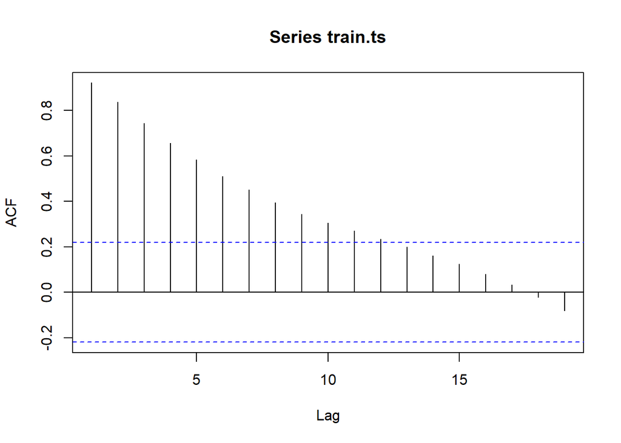

```r
acf(train.ts)
```

Plot ACF menunjukkan penurunan yang lambat pada lag nya. Hal ini mengindikasikan data tak stasioner dalam rataan.

## Uji ADF

```r
tseries::adf.test(train.ts)
```

```
##
##  Augmented Dickey-Fuller Test
##
## data:  train.ts
## Dickey-Fuller = 1.7235, Lag order = 4, p-value = 0.99
## alternative hypothesis: stationary
```

$H_0$ : Data tidak stasioner dalam rataan

$H_1$ : Data stasioner dalam rataan

Berdasarkan uji ADF tersebut, didapat *p-value* lebih besar dari taraf nyata 5% sehingga Tak Tolak $H_0$ dan menandakan bahwa **data tidak stasioner dalam rataan**. Hal ini sesuai dengan hasil eksplorasi menggunakan plot time series penuh dan plot ACF.

## Plot Box-Cox

```r
index <- seq_along(train.ts)

# Uji Box-Cox
bc <- boxcox(
  train.ts ~ index,
  lambda = seq(-2,2, by = 0.1)
)
```

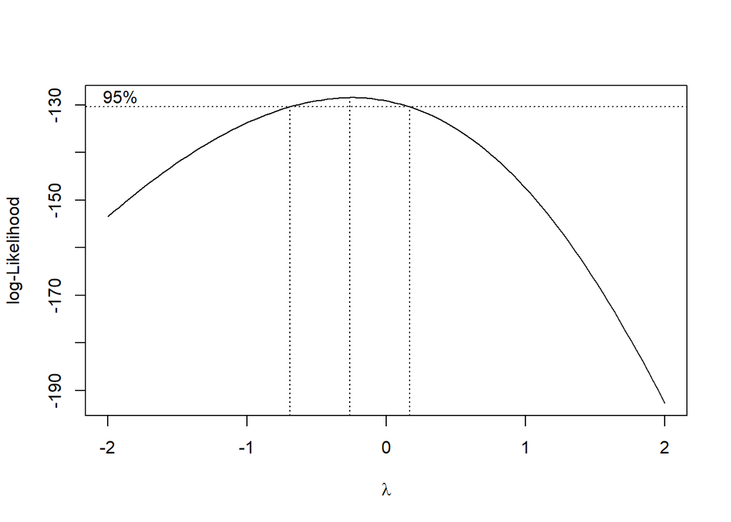

```r
# Nilai lambda optimum
lambda <- bc$x[which.max(bc$y)]
lambda
```

```
## [1] -0.2626263
```

```r
# Selang kepercayaan 95% untuk lambda
ci_lambda <- bc$x[bc$y > max(bc$y) - 0.5 * qchisq(0.95, 1)]

# Batas bawah dan batas atas
ci_lower <- min(ci_lambda)
ci_upper <- max(ci_lambda)

c(Batas_Bawah = ci_lower, Batas_Atas = ci_upper)
```

```
## Batas_Bawah  Batas_Atas
##  -0.6666667   0.1414141
```

Selang lambda tidak mengandung satu [-0.6666667, 0.1414141] sehingga **data tidak stasioner juga dalam ragam.**

# Penanganan Ketidakstasioneran

Dalam analisis deret waktu, differencing merupakan salah satu prosedur transformasi yang digunakan untuk memperoleh sifat stasioneritas dalam rataan. Metode ini dilakukan dengan menghitung selisih nilai observasi antar periode sehingga pola tren atau ketidakstasioneran dalam rataan dapat dieliminasi.

Secara umum, pembedaan pertama ditulis sebagai:

$$\nabla Y_t = Y_t - Y_{t-1}$$

Jika tren linier masih tersisa/ belum stasioner, dapat dilakukan differencing kedua:
$$\nabla^2 Y_t = \nabla (\nabla Y_t) = Y_t - 2Y_{t-1} + Y_{t-2}$$

## Diferensiasi Pertama

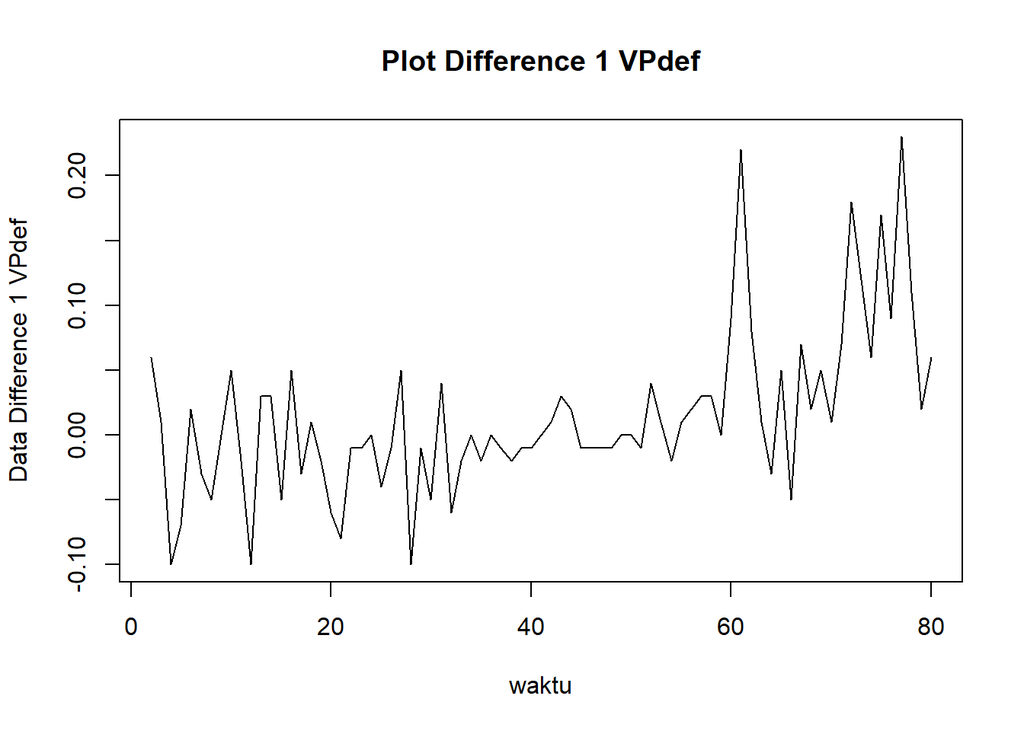

```r
train.diff1<-diff(train.ts,differences = 1)
plot.ts(train.diff1, lty=1, xlab="waktu", ylab="Data Difference 1 VPdef", main="Plot Difference 1 VPdef")
```

**Plot ACF**

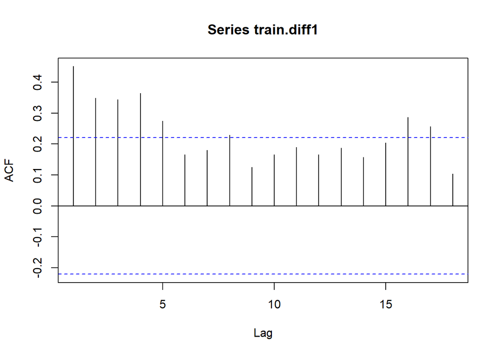

```r
acf(train.diff1)
```

Plot ACF masih menunjukkan indikasi data belum stasioner dalam rataan.

**Uji ADF**

```r
tseries::adf.test(train.diff1)
```

```
##
##  Augmented Dickey-Fuller Test
##
## data:  train.diff1
## Dickey-Fuller = -3.0834, Lag order = 4, p-value = 0.1326
## alternative hypothesis: stationary
```

$H_0$ : Data tidak stasioner dalam rataan

$H_1$ : Data stasioner dalam rataan

Berdasarkan uji ADF tersebut, didapat *p-value* lebih besar dari taraf nyata 5% sehingga Tak Tolak $H_0$ dan menandakan bahwa **data tidak stasioner dalam rataan**. Sehingga perlu dilakukan diferensiasi kedua.

## Diferensiasi Kedua

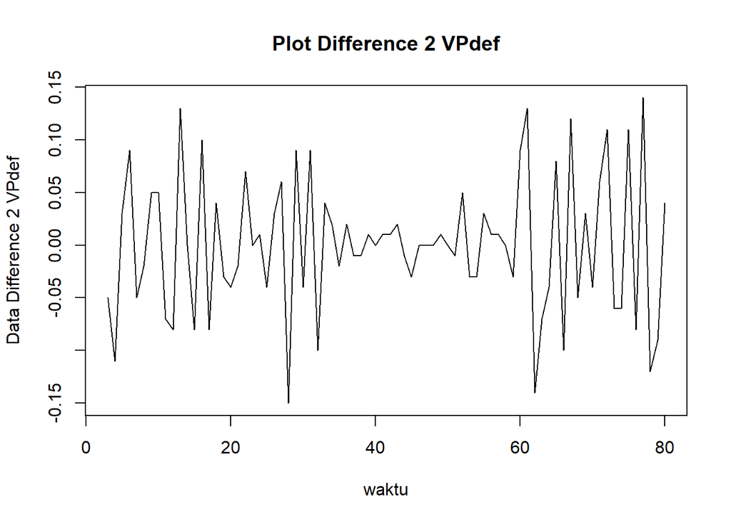

```r
train.diff2<-diff(train.ts,differences = 2)
plot.ts(train.diff2, lty=1, xlab="waktu", ylab="Data Difference 2 VPdef", main="Plot Difference 2 VPdef")
```

**Plot ACF**

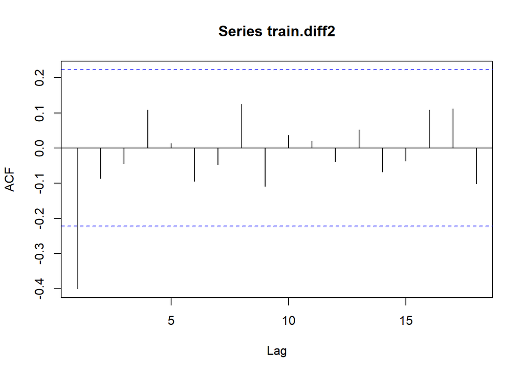

```r
acf(train.diff2)
```

**Plot ADF**

```r
tseries::adf.test(train.diff2)
```

```
##
##  Augmented Dickey-Fuller Test
##
## data:  train.diff2
## Dickey-Fuller = -5.0878, Lag order = 4, p-value = 0.01
## alternative hypothesis: stationary
```

$H_0$ : Data tidak stasioner dalam rataan

$H_1$ : Data stasioner dalam rataan

Berdasarkan uji ADF tersebut, didapat *p-value* sebesar 0.01 yang lebih kecil dari taraf nyata 5% sehingga Tolak $H_0$ dan menandakan bahwa **data sudah stasioner dalam rataan**.

**Plot Box-Cox**

```r
min(train.diff2)
```

```
## [1] -0.15
```

```r
index <- seq_along(train.diff2)

# Uji Box-Cox
bc <- boxcox(
  (train.diff2 - min(train.diff2) + 0.16) ~ index,
  lambda = seq(-2, 2, by = 0.1)
)
```

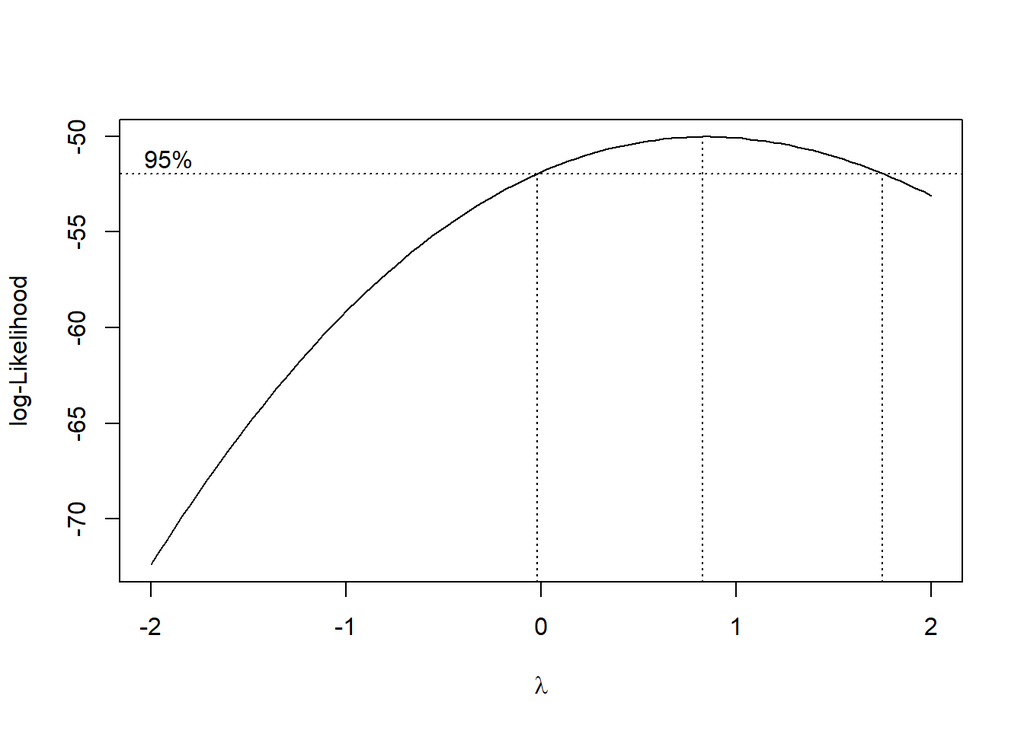

```r
# Nilai lambda optimum
lambda <- bc$x[which.max(bc$y)]
lambda
```

```
## [1] 0.8282828
```

```r
# Selang kepercayaan 95% untuk lambda
ci_lambda <- bc$x[bc$y > max(bc$y) - 0.5 * qchisq(0.95, 1)]

# Batas bawah dan batas atas
ci_lower <- min(ci_lambda)
ci_upper <- max(ci_lambda)

c(Batas_Bawah = ci_lower, Batas_Atas = ci_upper)
```

```
## Batas_Bawah  Batas_Atas
##  0.02020202  1.71717172
```

Selang lambda mengandung satu [0.02020202, 1.71717172] sehingga **data stasioner dalam ragam** juga setelah diferensiasi 2 kali.

## Simpulan

Data cuaca 100 baris pertama (peubah VPdef) memiliki plot deret waktu yang mengindikasikan pola yang tidak stasioner baik dalam rataan maupun ragam. Hal ini terbukti dengan plot ACF yang mengalami penurunan secara lambat pada lagnya, Uji ADF dengan p-value lebih besar dari 5% serta selang kepercayaan lambda pada plot Box-cox tidak mengandung nilai 1.

Setelah dilakukan diferensiasi 1 kali, stasioneritas rataan belum teratasi dan dilanjut percobaan dengan diferensiasi 2 kali. Hasilnya data stasioner dalam rataan berdasarkan nilai p-value uji ADF sebesar 0.01 yang lebih kecil dari 5% dan plot Box-cox yang mengandung nilai satu dalam selang kepercayaannya.

# Identifikasi Model

## Plot ACF

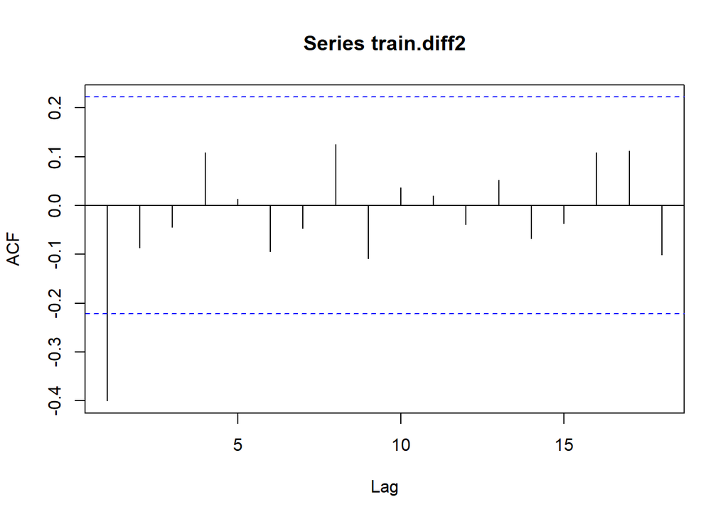

```r
acf(train.diff2)
```

Berdasarkan plot tersebut, terlihat bahwa plot ACF cenderung *cuts off* pada lag ke 1, sehingga jika plot PACF dianggap *tails of*, maka model tentatifnya adalah ARIMA(0,2,1).

## Plot PACF

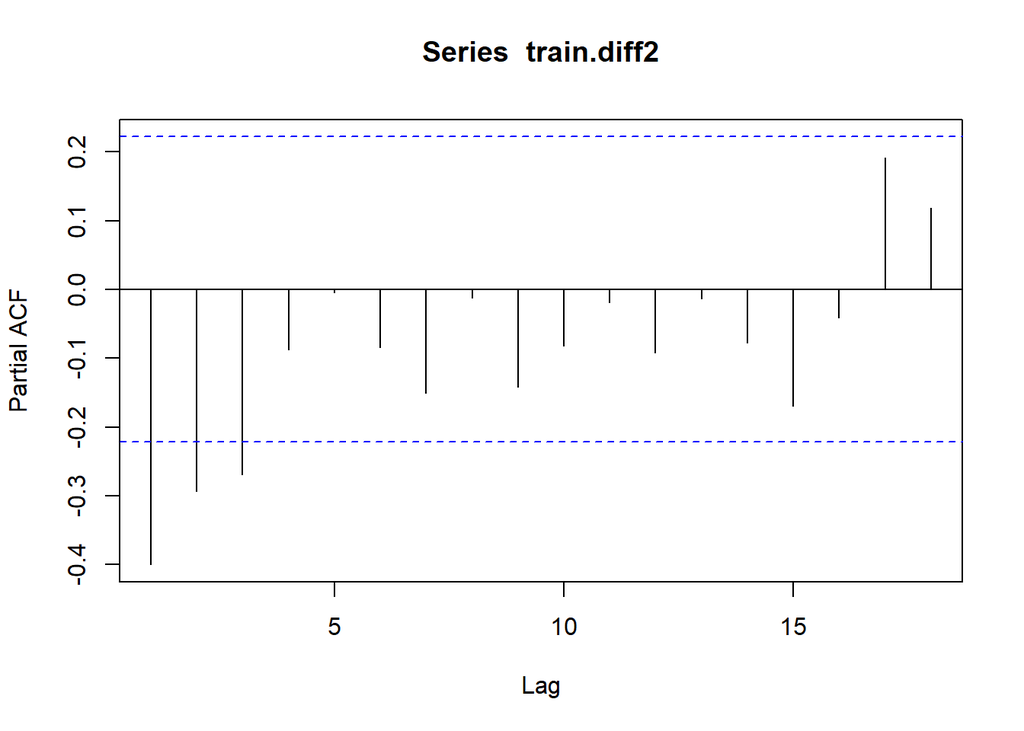

```r
pacf(train.diff2)
```

Berdasarkan plot tersebut, terlihat bahwa plot PACF cenderung *tails off* pada lag ke 1, sehingga model yang terbentuk adalah ARIMA(0,2,1)

## Plot EACF

```r
eacf(train.diff2)
```

```
## AR/MA
##   0 1 2 3 4 5 6 7 8 9 10 11 12 13
## 0 x o o o o o o o o o o  o  o  o
## 1 x o o o o o o o o o o  o  o  o
## 2 x o x o o o o o o o o  o  o  o
## 3 x o x x o o o o o o o  o  o  o
## 4 x o o x o o o o o o o  o  o  o
## 5 x o o o o o o o o o o  o  o  o
## 6 x o x o o x o o o o o  o  o  o
## 7 o x x o o o o o o o o  o  o  o
```

Identifikasi model menggunakan plot EACF dilakukan dengan melihat ujung segitiga pada pola segitiga nol. Dalam hal ini model tentatif yang terbentuk adalah ARIMA(1,2,1), ARIMA(2,2,1), ARIMA(2,2,3)ndan ARIMA(3,2,4).

# Pendugaan Parameter Model Tentatif

## 1. ARIMA(0,2,1)

```r
model1=Arima(train.diff2, order=c(0,0,1),method="ML")
summary(model1) #AIC=-233.06
```

```
## Series: train.diff2
## ARIMA(0,0,1) with non-zero mean
##
## Coefficients:
##           ma1    mean
##       -0.8912  0.0015
## s.e.   0.0587  0.0007
##
## sigma^2 = 0.002747:  log likelihood = 119.53
## AIC=-233.06   AICc=-232.74   BIC=-225.99
##
## Training set error measures:
##                        ME       RMSE        MAE  MPE MAPE      MASE      ACF1
## Training set -0.002712563 0.05173916 0.03633459 -Inf  Inf 0.4490792 0.1233102
```

```r
lmtest::coeftest(model1) #seluruh parameter signifikan
```

```
##
## z test of coefficients:
##
##              Estimate  Std. Error  z value Pr(>|z|)
## ma1       -0.89123783  0.05868404 -15.1871  < 2e-16 ***
## intercept  0.00153711  0.00072633   2.1163  0.03432 *
## ---
## Signif. codes:  0 '***' 0.001 '**' 0.01 '*' 0.05 '.' 0.1 ' ' 1
```

## 2. ARIMA(1,2,1)

```r
model2=Arima(train.diff2, order=c(1,0,1),method="ML")
summary(model2) #AIC=-232.14
```

```
## Series: train.diff2
## ARIMA(1,0,1) with non-zero mean
##
## Coefficients:
##          ar1      ma1    mean
##       0.1335  -0.9190  0.0015
## s.e.  0.1303   0.0624  0.0007
##
## sigma^2 = 0.002745:  log likelihood = 120.07
## AIC=-232.14   AICc=-231.59   BIC=-222.71
##
## Training set error measures:
##                       ME       RMSE        MAE  MPE MAPE      MASE       ACF1
## Training set -0.00316973 0.05137257 0.03640934 -Inf  Inf 0.4500031 0.02339214
```

```r
lmtest::coeftest(model2) #terdapat parameter tak signifikan
```

```
##
## z test of coefficients:
##
##              Estimate  Std. Error  z value Pr(>|z|)
## ar1        0.13347109  0.13034718   1.0240  0.30585
## ma1       -0.91899645  0.06243515 -14.7192  < 2e-16 ***
## intercept  0.00151584  0.00065426   2.3169  0.02051 *
## ---
## Signif. codes:  0 '***' 0.001 '**' 0.01 '*' 0.05 '.' 0.1 ' ' 1
```

## 3. ARIMA(2,2,1)

```r
model3=Arima(train.diff2, order=c(2,0,1),method="ML")
summary(model3) #AIC=-230.52
```

```
## Series: train.diff2
## ARIMA(2,0,1) with non-zero mean
##
## Coefficients:
##          ar1      ar2      ma1    mean
##       0.1197  -0.0820  -0.8991  0.0016
## s.e.  0.1304   0.1308   0.0692  0.0007
##
## sigma^2 = 0.002769:  log likelihood = 120.26
## AIC=-230.52   AICc=-229.69   BIC=-218.74
##
## Training set error measures:
##                        ME       RMSE        MAE  MPE MAPE      MASE       ACF1
## Training set -0.002761828 0.05125359 0.03632559 -Inf  Inf 0.4489679 0.01469307
```

```r
lmtest::coeftest(model3) #terdapat parameter tak signifikan
```

```
##
## z test of coefficients:
##
##              Estimate  Std. Error  z value Pr(>|z|)
## ar1        0.11966917  0.13043619   0.9175  0.35890
## ar2       -0.08203854  0.13082158  -0.6271  0.53059
## ma1       -0.89910961  0.06919870 -12.9932  < 2e-16 ***
## intercept  0.00155073  0.00070521   2.1990  0.02788 *
## ---
## Signif. codes:  0 '***' 0.001 '**' 0.01 '*' 0.05 '.' 0.1 ' ' 1
```

## 4. ARIMA(2,2,3)

```r
model4=Arima(train.diff2, order=c(2,0,3),method="ML")
summary(model4) #AIC=-230
```

```
## Series: train.diff2
## ARIMA(2,0,3) with non-zero mean
##
## Coefficients:
##           ar1      ar2      ma1     ma2      ma3    mean
##       -0.6634  -0.8424  -0.0917  0.1982  -0.8415  0.0016
## s.e.   0.1129   0.1289   0.1021  0.1274   0.1007  0.0007
##
## sigma^2 = 0.002694:  log likelihood = 122
## AIC=-230   AICc=-228.4   BIC=-213.5
##
## Training set error measures:
##                        ME       RMSE        MAE  MPE MAPE      MASE        ACF1
## Training set -0.002740488 0.04986855 0.03467284 -Inf  Inf 0.4285407 0.009649986
```

```r
lmtest::coeftest(model4) #terdapat parameter tidak signifikan
```

```
##
## z test of coefficients:
##
##              Estimate  Std. Error z value  Pr(>|z|)
## ar1       -0.66343480  0.11287471 -5.8776 4.162e-09 ***
## ar2       -0.84244970  0.12894469 -6.5334 6.428e-11 ***
## ma1       -0.09167706  0.10210842 -0.8978   0.36927
## ma2        0.19824314  0.12740023  1.5561   0.11969
## ma3       -0.84146732  0.10074637 -8.3523 < 2.2e-16 ***
## intercept  0.00157233  0.00069427  2.2647   0.02353 *
## ---
## Signif. codes:  0 '***' 0.001 '**' 0.01 '*' 0.05 '.' 0.1 ' ' 1
```

## 5. ARIMA(3,2,4)

```r
model5=Arima(train.diff2, order=c(3,0,4),method="ML")
summary(model5) #AIC=-226
```

```
## Series: train.diff2
## ARIMA(3,0,4) with non-zero mean
##
## Coefficients:
```

```
##           ar1      ar2      ar3     ma1     ma2      ma3      ma4    mean
##       -0.9501  -1.0325  -0.2427  0.1934  0.1719  -0.7839  -0.2395  0.0016
## s.e.      NaN      NaN      NaN     NaN     NaN      NaN      NaN  0.0007
##
## sigma^2 = 0.002771:  log likelihood = 122
## AIC=-226   AICc=-223.35   BIC=-204.79
##
## Training set error measures:
##                        ME       RMSE        MAE  MPE MAPE      MASE       ACF1
## Training set -0.002733989 0.04986896 0.03466528 -Inf  Inf 0.4284472 0.01118717
```

```r
lmtest::coeftest(model5) #erdapat parameter tidak signifikan
```

```
##
## z test of coefficients:
##
##              Estimate  Std. Error z value Pr(>|z|)
## ar1       -0.95011725         NaN     NaN      NaN
## ar2       -1.03246102         NaN     NaN      NaN
## ar3       -0.24266276         NaN     NaN      NaN
## ma1        0.19341785         NaN     NaN      NaN
## ma2        0.17191794         NaN     NaN      NaN
## ma3       -0.78394657         NaN     NaN      NaN
## ma4       -0.23950213         NaN     NaN      NaN
## intercept  0.00157272  0.00069513  2.2625  0.02367 *
## ---
## Signif. codes:  0 '***' 0.001 '**' 0.01 '*' 0.05 '.' 0.1 ' ' 1
```

Berdasarkan pendugaan parameter di atas, nilai AIC terkecil dimiliki oleh model ARIMA(0,2,1) dan parameter modelnya juga seluruhnya signifikan, sehingga model yang dipilih adalah model ARIMA(0,2,1).

# Analisis Sisaan

Model terbaik hasil identifikasi kemudian dicek asumsi sisaannya. Sisaan model ARIMA harus memenuhi asumsi normalitas, kebebasan sisaan, dan kehomogenan ragam. Diagnostik model dilakukan secara eksplorasi dan uji formal.

## Eksplorasi Sisaan

**ARIMA (0,2,1)**

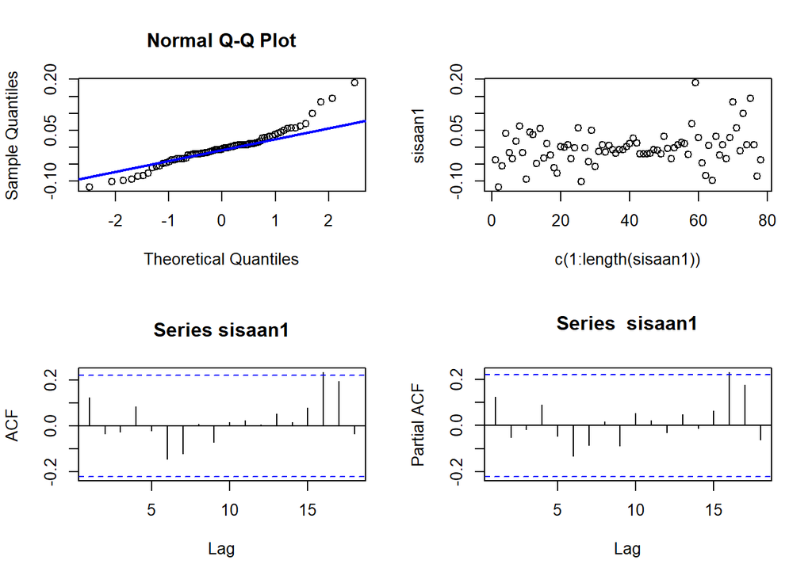

```r
#Eksplorasi
sisaan1 <- model1$residuals
par(mfrow=c(2,2))
qqnorm(sisaan1)
qqline(sisaan1, col = "blue", lwd = 2)
plot(c(1:length(sisaan1)),sisaan1)
acf(sisaan1)
pacf(sisaan1)
```

```r
par(mfrow = c(1,1))
```

Berdasarkan plot kuantil-kuantil normal, secara eksplorasi ditunjukkan sisaan tidak menyebar normal ditandai dengan titik titik yang cenderung tidak mengikuti garis $45^{\circ}$. Sedangkan berdasarkan lebar pita plot sisaan, homoskedastisitas dan nilai harapan nol terpenuhi. Lalu pada plot ACF dan PACF mengindikasikan tidak terdapat autokorelasi.

## Uji Formal

```r
#1) Sisaan Menyebar Normal
ks.test(sisaan1,"pnorm")# tolak H0 > sisaan tidak menyebar normal
```

```
##
##  Exact one-sample Kolmogorov-Smirnov test
##
## data:  sisaan1
## D = 0.45305, p-value = 3.442e-15
## alternative hypothesis: two-sided
```

Hipotesis pada uji KS

$H_0$ : Sisaan menyebar normal

$H_1$ : Sisaan tidak menyebar normal

Berdasarkan uji KS tersebut, didapat *p-value* sebesar 3.442e-15 yang kurang dari taraf nyata 5% sehingga tolak $H_0$ dan menandakan bahwa **sisaan tidak menyebar normal**. Hal ini sesuai dengan hasil eksplorasi menggunakan plot kuantil-kuantil normal.

```r
#2) Sisaan saling bebas/tidak ada autokorelasi
Box.test(sisaan1, type = "Ljung")#tak tolak H0 > sisaan saling bebas
```

```
##
##  Box-Ljung test
##
## data:  sisaan1
## X-squared = 1.2322, df = 1, p-value = 0.267
```

Selanjutnya akan dilakukan uji formal untuk kebebasan sisaan menggunakan uji Ljung-Box. Hipotesis yang digunakan adalah sebagai berikut.

$H_0$ : Sisaan saling bebas

$H_1$ : Sisaan tidak tidak saling bebas

Berdasarkan uji Ljung-Box tersebut, didapat *p-value* sebesar 0.267 yang lebih besar dari taraf nyata 5% sehingga tak tolak $H_0$ dan menandakan bahwa **sisaan saling bebas**. Hal ini sesuai dengan eksplorasi.

```r
#3) Sisaan homogen
Box.test((sisaan1)^2, type = "Ljung")#tolak H0 > ragam sisaan homogen
```

```
##
##  Box-Ljung test
##
## data:  (sisaan1)^2
## X-squared = 0.057048, df = 1, p-value = 0.8112
```

Hipotesis yang digunakan untuk uji kehomogenan ragam adalah sebagai berikut.

$H_0$ : Ragam sisaan homogen

$H_1$ : Ragam sisaan tidak homogen

```r
#4) Nilai tengah sisaan sama dengan nol
t.test(sisaan1, mu = 0, conf.level = 0.95)#tak tolak h0 > nilai tengah sisaan sama dengan 0
```

```
##
##  One Sample t-test
##
## data:  sisaan1
## t = -0.46068, df = 77, p-value = 0.6463
## alternative hypothesis: true mean is not equal to 0
## 95 percent confidence interval:
##  -0.014437299  0.009012173
## sample estimates:
##    mean of x
## -0.002712563
```

Terakhir, dengan uji-t, akan dicek apakah nilai tengah sisaan sama dengan nol. Hipotesis yang diujikan sebagai berikut.

$H_0$ : nilai tengah sisaan sama dengan 0

$H_1$ : nilai tengah sisaan tidak sama dengan 0

## Simpulan

Model ARIMA (0,2,1) tidak memenuhi asumsi kenormalan sisaan.

# Overfitting

Pada model tentatif, terdapat model overfitting yang sudah dicek, yaitu ARIMA (2,2,1). Hasilnya tidak lebih baik dari model yang dipilih karena nilai AIC nya lebih besar dan terdapat parameter yang tak signifikan di dalam modelnya. Selanjutnya sebagai eksplorasi tambahan akan dicek model overfitting lainyya yaitu **ARIMA (0,2,2)**.

```r
model.ovt=Arima(train.diff2, order=c(0,0,2),method="ML")
summary(model.ovt) #AIC=-232.28
```

```
## Series: train.diff2
## ARIMA(0,0,2) with non-zero mean
##
## Coefficients:
##           ma1      ma2    mean
##       -0.7729  -0.1329  0.0015
## s.e.   0.1174   0.1180  0.0007
##
## sigma^2 = 0.00274:  log likelihood = 120.14
## AIC=-232.28   AICc=-231.74   BIC=-222.86
##
## Training set error measures:
##                        ME       RMSE        MAE  MPE MAPE      MASE       ACF1
## Training set -0.003136109 0.05132406 0.03644797 -Inf  Inf 0.4504806 0.01023722
```

```r
lmtest::coeftest(model.ovt) #terdapat parameter tak signifikan
```

```
##
## z test of coefficients:
##
##              Estimate  Std. Error z value  Pr(>|z|)
## ma1       -0.77288639  0.11738587 -6.5842 4.575e-11 ***
## ma2       -0.13287237  0.11803638 -1.1257   0.26030
## intercept  0.00152210  0.00065651  2.3185   0.02042 *
## ---
## Signif. codes:  0 '***' 0.001 '**' 0.01 '*' 0.05 '.' 0.1 ' ' 1
```

Hasil ARIMA (0,2,2) juga tidak lebih baik, sehingga model terbaik tetap ARIMA (0,2,1)’

# Peramalan

Peramalan dilakukan menggunakan fungsi `forecast()` . Contoh peramalan berikut ini dilakukan untuk 2 jam kedepan.

```r
#---FORECAST---#
ramal <- forecast::forecast(model1, h = 12)
ramal
```

```
##    Point Forecast       Lo 80      Hi 80       Lo 95     Hi 95
## 81    0.034987707 -0.03218548 0.10216090 -0.06774482 0.1377202
## 82    0.001537115 -0.08844249 0.09151672 -0.13607481 0.1391490
## 83    0.001537115 -0.08844249 0.09151672 -0.13607481 0.1391490
## 84    0.001537115 -0.08844249 0.09151672 -0.13607481 0.1391490
## 85    0.001537115 -0.08844249 0.09151672 -0.13607481 0.1391490
## 86    0.001537115 -0.08844249 0.09151672 -0.13607481 0.1391490
## 87    0.001537115 -0.08844249 0.09151672 -0.13607481 0.1391490
## 88    0.001537115 -0.08844249 0.09151672 -0.13607481 0.1391490
## 89    0.001537115 -0.08844249 0.09151672 -0.13607481 0.1391490
## 90    0.001537115 -0.08844249 0.09151672 -0.13607481 0.1391490
## 91    0.001537115 -0.08844249 0.09151672 -0.13607481 0.1391490
## 92    0.001537115 -0.08844249 0.09151672 -0.13607481 0.1391490
```

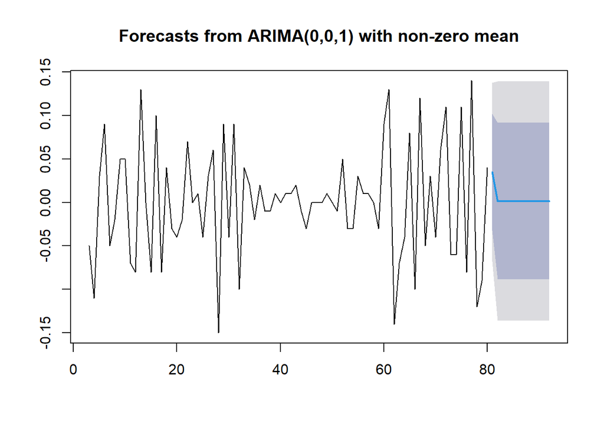

```r
data.ramal<- ramal$mean
plot(ramal)
```

Berdasarkan hasil plot ramalan di atas, dapat dilihat bahwa ramalan ARIMA(0,2,1) cenderung stabil hingga akhir periode. Selanjutnya, dapat dicari nilai akurasi antara hasil ramalan dengan data uji sebagai berikut.

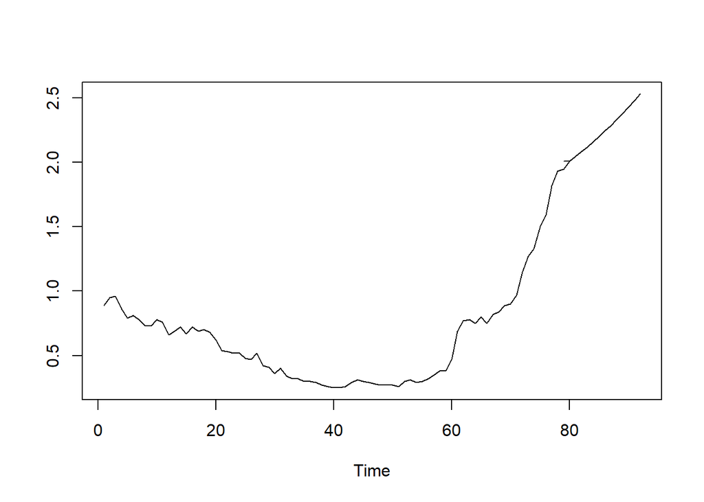

```r
pt_1 <- train.ts[80] #nilai akhir data latih
hasil.forc.Diff <- data.ramal
hasil <- diffinv(hasil.forc.Diff, differences = 2) + pt_1
#has.1 sama hasilnta dengan: cumsum(c(pt_1,hasil.forc.Diff))
ts.plot(train.ts,hasil)
```

```r
perbandingan<-matrix(data=c(head(test.ts, n=12), hasil[-1]),
                     nrow = 12, ncol = 2)
colnames(perbandingan)<-c("Aktual","Hasil Forecast")
perbandingan
```

```
##       Aktual Hasil Forecast
##  [1,]   2.34       2.010000
##  [2,]   2.36       2.044988
##  [3,]   2.45       2.081513
##  [4,]   2.33       2.119574
##  [5,]   2.18       2.159174
##  [6,]   2.27       2.200310
##  [7,]   2.40       2.242983
##  [8,]   2.39       2.287193
##  [9,]   2.58       2.332941
## [10,]   2.70       2.380225
## [11,]   2.52       2.429047
## [12,]   2.43       2.479406
```

```r
accuracy(ts(hasil[-1]), head(test.ts, n=12))
```

```
##                 ME      RMSE       MAE    MPE     MAPE      ACF1 Theil's U
## Test set 0.1818872 0.2241123 0.1901215 7.4489 7.787762 0.3910231  1.767051
```

Model ARIMA (0,2,1) memiliki nilai MAPE kurang dari 10% sebesar 7,79%, performa model baik untuk peramalan.